# Matriz origen-destino

Andrés Martínez González

2026-04-10

Hipotesis: a mayor nivel de ingresos los viajes son más cortos, mientras que a menor nivel de ingresos los viajes son más largos

## Datos por municipio

Lectura de la base de datos estructurada

```r
leer_movilidad <- function(granularidad = "municipio") {
  return(read.csv(
    file.path(ruta_data, paste0(granularidad, "-interno.csv"))))
}

movilidad_mun <- leer_movilidad()
head(movilidad_mun)
```

```
##   source target    w
## 1  31002  31013    5
## 2  31002  31038   15
## 3  31002  31039    1
## 4  31002  31041  158
## 5  31002  31050 4018
## 6  31002  31090   29
```

### Matriz origen-destino por municipio

Creación del dataframe con la Matriz origen-destino, las filas corresponden al origen o salida y las columnas al destino o llegada

```r
matriz_od <- function(df_movilidad) {
  orden <- sort(unique(df_movilidad$source))

  return(df_movilidad |>
    mutate(source = factor(source, levels = orden),
           target = factor(target, levels = orden)) |>
    group_by(source, target, .drop = FALSE) |>
    summarise(w = sum(w), .groups = 'drop') |>
    pivot_wider(names_from = target, values_from = w, values_fill = 0))
}

matriz_od_mun <- matriz_od(movilidad_mun)
print(matriz_od_mun)
```

```
## # A tibble: 13 × 14
##    source `31002` `31013` `31020` `31038` `31039` `31041` `31050` `31063`
##    <fct>    <int>   <int>   <int>   <int>   <int>   <int>   <int>   <int>
##  1 31002        0       5       0      15       1     158    4018       0
##  2 31013        4       0      42     109      47      29   29749       0
##  3 31020        0      33       0       0    1694       9    1061       0
##  4 31038       17      99       0       0       3     103   16529      99
##  5 31039        1      27    1630       4       0      12    4033       0
##  6 31041      158      28      11      93      12       0   70432      23
##  7 31050     3874   30575    1056   15926    3794   69383       0    1036
##  8 31063        0       0       0      89       0      22    1113       0
##  9 31090       39       0       0       0       0     315    3850       0
## 10 31093       15      10       5       9       0     176    7486       0
## 11 31095        9       2       0       0       0    1095    1801       1
## 12 31100        0       2       0     273       0      11    2291       5
## 13 31101       47       9       1     150       2    1090   39207     452
## # ℹ 5 more variables: `31090` <int>, `31093` <int>, `31095` <int>,
## #   `31100` <int>, `31101` <int>
```

Creación de la visualización de Mapa de calor de la Matríz origen destino.

Se configuró para que el gradiente de la escala de colores llegué al límite de 50,000, es decir los valores de 50 mil o más tendrán el gradiente más alto.

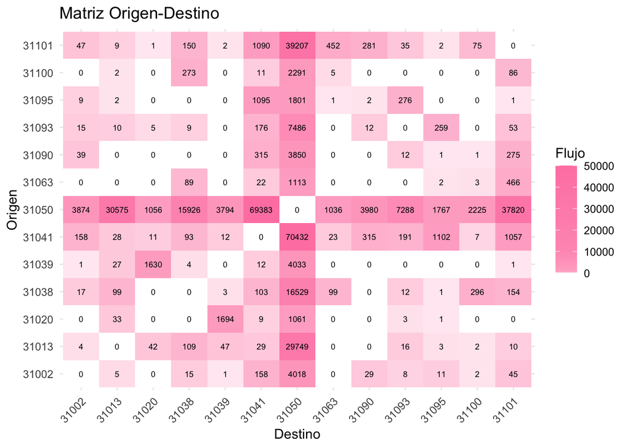

```r
mapa_calor <- function(matriz_od) {
  matriz_long <- melt(matriz_od,
                      id.vars = "source",
                      variable.name = "target",
                      value.name = "flujo")

  ggplot(matriz_long, aes(x = target, y = source, fill = flujo)) +
    geom_tile() +
    scale_fill_gradientn(name = "Flujo",
                         limits = c(0, 50000),
                         oob = scales::squish,
                         colors = c("#FFFFFF", "#FF85B2"),
                         values = scales::rescale(
                           c(0, 1, 10, 100, 1000, 10000, 50000))) +
    geom_text(aes(label = flujo), size = 2.3) +
    theme_minimal() +
    theme(axis.text.x = element_text(angle = 45, hjust = 1)) +
    labs(title = "Matriz Origen-Destino", x = "Destino", y = "Origen")
}

mapa_calor(matriz_od_mun)
```

## Datos por localidad

Los datos se estructuraron a partir de las bases de datos de agebs agrupados por ageb y municipio, lo que permite obtener los movimientos dentro del mismo municipio.

### Matriz origen-destino por municipio, obtenidos de localidades

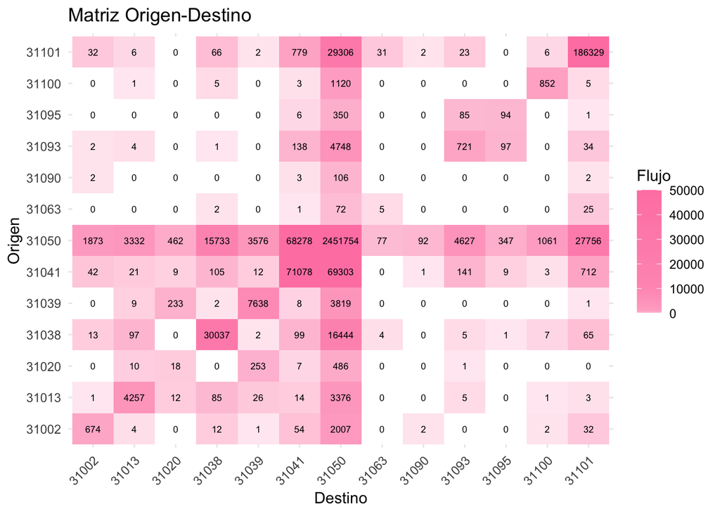

```r
movilidad_loc <- leer_movilidad('localidad')
#head(movilidad_loc)

movilidad_mun_loc = movilidad_loc |>
  group_by(source = substr(source, 1, 5),
           target = substr(target, 1, 5)) |>
  summarise(w = sum(w, na.rm = TRUE), .groups = "drop")
#head(movilidad_mun_loc)

matriz_od_mun_loc <- matriz_od(movilidad_mun_loc)
#print(matriz_od_mun_loc)

mapa_calor(matriz_od_mun_loc)
```

### Matriz origen-destino por localidad

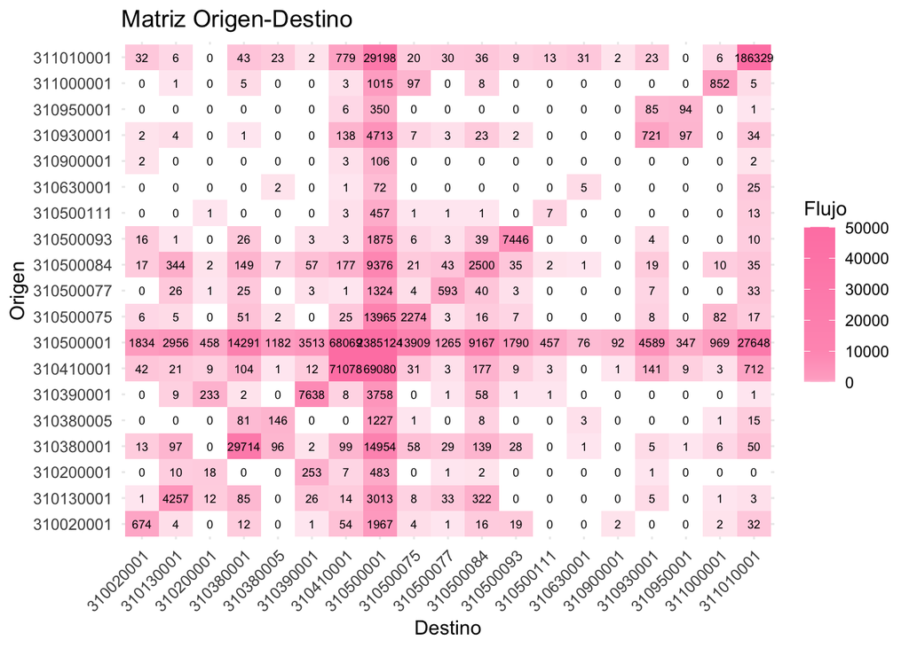

```r
matriz_od_loc <- matriz_od(movilidad_loc)
#print(matriz_od_loc)
mapa_calor(matriz_od_loc)
```

## Con vectores

```r
cabeceras <- st_read(file.path(ruta_data, "cabeceras_municipales.gpkg"))
head(cabeceras)
```

```
## Simple feature collection with 6 features and 10 fields
## Geometry type: POINT
## Dimension:     XY
## Bounding box:  xmin: 199506.1 ymin: 2303370 xmax: 251019.9 ymax: 2328134
## Projected CRS: WGS 84 / UTM zone 16N
##                                        id g_id cve_ent nom_ent cve_mun
## 1  gref_cabeceras_municipales_20_loc_p.80   80      31 Yucatán     101
## 2  gref_cabeceras_municipales_20_loc_p.81   81      31 Yucatán     100
## 3  gref_cabeceras_municipales_20_loc_p.86   86      31 Yucatán     095
## 4  gref_cabeceras_municipales_20_loc_p.88   88      31 Yucatán     093
## 5  gref_cabeceras_municipales_20_loc_p.91   91      31 Yucatán     090
## 6 gref_cabeceras_municipales_20_loc_p.118  118      31 Yucatán     063
##   cvegeomun   nom_mun nom_cabecera    x_long    y_lat                     geom
## 1     31101      Umán         Umán -89.74809 20.88138 POINT (214085.9 2311467)
## 2     31100       Ucú          Ucú -89.74622 21.03190 POINT (214569.7 2328134)
## 3     31095 Tixpéhual    Tixpéhual -89.44164 20.97871 POINT (246153.9 2321728)
## 4     31093  Tixkokob     Tixkokob -89.39518 21.00275 POINT (251019.9 2324312)
## 5     31090   Timucuy      Timucuy -89.51326 20.81189 POINT (238406.7 2303370)
## 6     31063   Samahil      Samahil -89.88818 20.88409 POINT (199506.1 2312022)
```

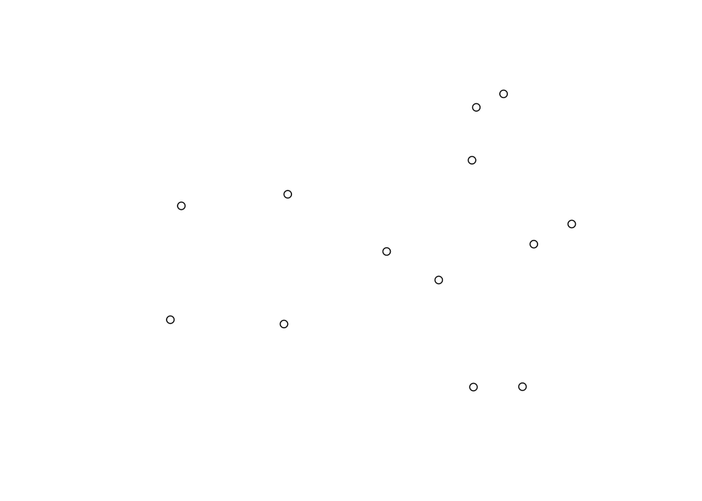

```r
plot(cabeceras$geom)
```